# Import and Export

Jin Hyuk Son

2024-10-21

```r
library(ezids)
library(tidyverse)
library(zoo)
```

### Data Description

```r
rice_df <- read.csv("Rice Production Data.csv")
```

Of the 36 variables included in the dataset, we will be using 9 variables in our project: Country, Year, Production(t), Population, Land Use, Import(t), Export(t), Domestic Supply(t), and Supply Chain Waste(t). The names of the variables were modified for better comprehensibility.

Displaying the first few observations:

```r
rice_df_clean <- rice_df %>%
  select(Country, Year, Population,
         Production..t., Land.Use..ha.,
         Imports..t., Exports..t.,
         Domestic.supply..t., Supply.chain.waste..t.) %>%
  rename("Production" = "Production..t.",
         "Land_Use" = "Land.Use..ha.",
         "Imports(t)" = "Imports..t.",
         "Exports(t)" = "Exports..t.",
         "Domestic_Supply(t)" = "Domestic.supply..t.",
         "Supply_Chain_Waste(t)" = "Supply.chain.waste..t.")
xkabledplyhead(rice_df_clean, 3)
```

Head

| Country | Year | Population | Production | Land_Use | Imports(t) | Exports(t) | Domestic_Supply(t) | Supply_Chain_Waste(t) |
| --- | --- | --- | --- | --- | --- | --- | --- | --- |
| Afghanistan | 1961 | 8790140 | 319000 | 210000 | 0 | NA | 213000 | 15000 |
| Afghanistan | 1962 | 8969055 | 319000 | 210000 | 0 | NA | 213000 | 15000 |
| Afghanistan | 1963 | 9157463 | 319000 | 210000 | 0 | NA | 213000 | 15000 |

Displaying the summary of the dataset

```r
summary(rice_df_clean)
```

```
##    Country               Year        Population         Production
##  Length:13503       Min.   :1961   Min.   :1.22e+04   Min.   :0.00e+00
##  Class :character   1st Qu.:1977   1st Qu.:2.39e+06   1st Qu.:2.41e+04
##  Mode  :character   Median :1993   Median :1.02e+07   Median :3.04e+05
##                     Mean   :1992   Mean   :1.71e+08   Mean   :2.09e+07
##                     3rd Qu.:2008   3rd Qu.:5.37e+07   3rd Qu.:3.18e+06
##                     Max.   :2022   Max.   :7.98e+09   Max.   :7.89e+08
##                                    NA's   :34         NA's   :3375
##     Land_Use          Imports(t)         Exports(t)       Domestic_Supply(t)
##  Min.   :0.00e+00   Min.   :       0   Min.   :       0   Min.   :   -72000
##  1st Qu.:1.10e+04   1st Qu.:    6000   1st Qu.:       0   1st Qu.:    22000
##  Median :1.12e+05   Median :   45000   Median :    2000   Median :   142000
##  Mean   :6.01e+06   Mean   :  822672   Mean   :  850699   Mean   : 12570499
##  3rd Qu.:9.93e+05   3rd Qu.:  347000   3rd Qu.:  112000   3rd Qu.:  1588000
##  Max.   :1.66e+08   Max.   :82227000   Max.   :76530000   Max.   :761276000
##  NA's   :3405       NA's   :759        NA's   :1721       NA's   :753
##  Supply_Chain_Waste(t)
##  Min.   :       0
##  1st Qu.:    1000
##  Median :    7000
##  Mean   :  778451
##  3rd Qu.:  109000
##  Max.   :33801000
##  NA's   :3094
```

The timeline for the project will be 1980 to 2022. The Country variable consists of individual countries, Food and Agricultural Organizations of UN (FAO), continents, and the global total. We have created a categorical variable to identify countries.

```r
rice_df_clean <- rice_df_clean %>%
  filter(Year >= 1980) %>%
  mutate(area_type = case_when(
    str_detect(Country, "FAO") ~ "Region",
    str_detect(Country, "(?i)countries") ~ "Region",
    str_detect(Country, "European Union") ~ "Region",
    str_detect(Country, "World") ~ "World",
    Country %in% c("North America", "South America",
                   "Asia", "Africa", "Europe",
                   "Oceania", "Antarctica", "Melanesia") ~ "Continent",
    TRUE ~ "Country"
  ))
```

### **Research Question 1**

To what extent did the global rice price crisis (2007-2008) affect log Import volumes in the 2000s compared to the 2010s, and how do import dependency ratios (IDR) differ across regions and population sizes during these periods?

```r
#Select columns of interest and clean NAs
trade_df <- rice_df_clean %>%
  select(Country, Year, Population,
         Production, `Imports(t)`, `Exports(t)`,
         area_type) %>%
  filter(Year >= 1980 & Year < 2022) #2021 the most recent data
#data cleaning
#if all production values is NA, set to 0
trade_df_cleaned <- trade_df %>%
  mutate(Production = if_else(
    Country %in%
      (
        trade_df %>%
          group_by(Country) %>%
          summarize(
            all_zero_or_na = all(is.na(Production) |
                                   Production == 0),
            .groups = 'drop'
          ) %>%
          filter(all_zero_or_na) %>%
          pull(Country)
      ),
    0,
    Production
  ))

#if all import values is NA, set to 0
trade_df_cleaned <- trade_df_cleaned %>%
  mutate(`Imports(t)` = if_else(
    Country %in%
      (
        trade_df_cleaned %>%
          group_by(Country) %>%
          summarize(
            all_zero_or_na = all(is.na(`Imports(t)`) |
                                   `Imports(t)` == 0),
            .groups = 'drop'
          ) %>%
          filter(all_zero_or_na) %>%
          pull(Country)
      ),
    0,
    `Imports(t)`
  ))
#if all import values is NA, set to 0
trade_df_cleaned <- trade_df_cleaned %>%
  mutate(`Exports(t)` = if_else(
    Country %in%
      (
        trade_df_cleaned %>%
          group_by(Country) %>%
          summarize(
            all_zero_or_na = all(is.na(`Exports(t)`) |
                                   `Exports(t)` == 0),
            .groups = 'drop'
          ) %>%
          filter(all_zero_or_na) %>%
          pull(Country)
      ),
    0,
    `Exports(t)`
  ))

# Calculate growth rates
population_data <- trade_df_cleaned %>%
  mutate(GrowthRate = (Population - lag(Population)) / lag(Population))

#calculating mean growth rate
average_growth_rate <- mean(population_data$GrowthRate, na.rm = TRUE)

#function to impute data based on calcualted growth rate
impute_population <- function(data, avg_growth) {
  for (i in 1:nrow(data)) {
    if (is.na(data$Population[i])) {
      previous_population <- data$Population[i - 1]  # Last known population
      data$Population[i] <- previous_population * (1 + avg_growth)  # Impute using growth rate
    }
  }
  return(data)
}

# Impute missing values
population_data <- impute_population(population_data, average_growth_rate)

#group by data to mutate the Import and Export for specific countries
population_data <- population_data %>%
  group_by(Country) %>%
  mutate(`Imports(t)` = na.approx(`Imports(t)`, na.rm = FALSE),
         `Exports(t)` = na.approx(`Exports(t)`, na.rm = FALSE)) %>%
  ungroup()

#fill in missing values in the Import and Export columns using interpolation
population_data$`Imports(t)` <- na.approx(population_data$`Imports(t)`, na.rm = FALSE)
population_data$`Exports(t)` <- na.approx(population_data$`Exports(t)`, na.rm = FALSE)

final_trade_df <- population_data %>%
  filter(!is.na(`Exports(t)`)) %>%
  select(-GrowthRate)
```

#### **Methods**

To conduct analysis on the research question, we have made the following additions to the dataset.

- **Percent Exported**. We have divided the export volume by production to analyze the growth of the global rice market.

```r
#Exported percentage
final_trade_df <- final_trade_df %>%
  mutate(`Percent Exported` = `Exports(t)` / Production * 100) %>%
  filter(!is.infinite(`Percent Exported`) & !is.na(`Percent Exported`))
```

- **Import Dependency Ratio (IDR)**. The Food and Agriculture Organization of the United Nations defines IDR as imports x 100/(production + imports - exports). A higher IDR indicates a greater reliance on imports for rice. We have categorized IDR as follows:
  - Very High: 50 or greater
  - High: 40-49
  - Medium: 30-39
  - Low: 20-29
  - Very Low: Below 20

```r
#Import dependency ratio
final_trade_df <- final_trade_df %>%
  mutate(IDR = `Imports(t)` * 100 /
           (Production + `Imports(t)` - `Exports(t)`)) %>%
  filter(!is.infinite(IDR) & !is.na(IDR))

#Giving tags for IDR and Population
##IDR
final_trade_df <- final_trade_df %>%
  mutate(`IDR Category` = case_when(
    IDR >= 50 ~ "Very High",
    IDR >= 40 ~ "High",
    IDR >= 30 ~ "Medium",
    IDR >= 20 ~ "Low",
    TRUE ~ "Very Low"
  ))
final_trade_df$`IDR Category` <-
  factor(final_trade_df$`IDR Category`,
         levels = c("Very Low", "Low",
                    "Medium", "High", "Very High"))
```

```r
##Population
final_trade_df <- final_trade_df %>%
  mutate(`Population Category` = case_when(
    Population < 10000000 ~ "Small",
    Population < 50000000 ~ "Medium",
    Population < 100000000 ~ "Large",
    TRUE ~ "Very Large"
  ))
final_trade_df$`Population Category` <-
  factor(final_trade_df$`Population Category`,
         levels = c("Small", "Medium", "Large"))
```

- **Region**. The continent to which each country belongs has been identified using the “countrycode” package.

```r
#Add region for each country
library(countrycode)
final_trade_df$Continent <- countrycode(sourcevar =
                                    final_trade_df$Country,
                                  origin = "country.name",
                                  destination = "continent")
final_trade_df$Continent <- as.factor(final_trade_df$Continent)
```

- **Log import.** Since the import variable is right-skewed, we applied a logarithmic transformation to achieve normality for hypothesis testing.

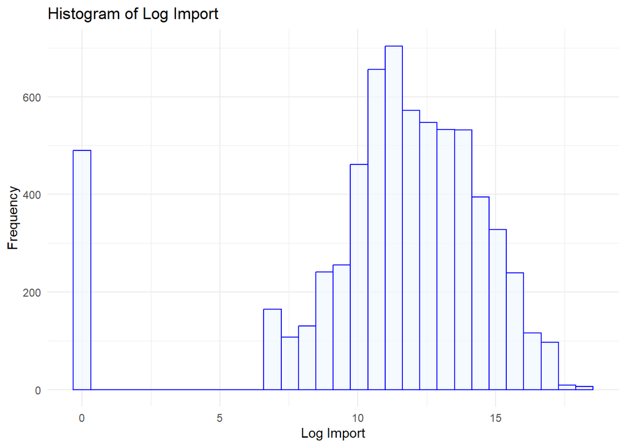

```r
final_trade_df <- final_trade_df %>%
  mutate(log_import = log(`Imports(t)` + 1))

#histogram of log_import
ggplot(data = final_trade_df, aes(log_import)) +
  geom_histogram(col="blue",
                 fill="aliceblue",
                 alpha = .7,
                 bins = 30) +
  labs(x="Log Import", y="Frequency") +
  labs(title="Histogram of Log Import") +
  theme_minimal()
```

Displaying the summary of the processed data:

```r
summary(final_trade_df)
```

```
##    Country               Year        Population         Production
##  Length:6583        Min.   :1980   Min.   :6.68e+04   Min.   :0.00e+00
##  Class :character   1st Qu.:1990   1st Qu.:6.87e+06   1st Qu.:4.52e+04
##  Mode  :character   Median :2001   Median :2.35e+07   Median :4.75e+05
##                     Mean   :2001   Mean   :2.68e+08   Mean   :2.56e+07
##                     3rd Qu.:2011   3rd Qu.:1.44e+08   3rd Qu.:4.38e+06
##                     Max.   :2021   Max.   :7.91e+09   Max.   :7.89e+08
##    Imports(t)         Exports(t)        area_type         Percent Exported
##  Min.   :       0   Min.   :       0   Length:6583        Min.   :0.00e+00
##  1st Qu.:   24000   1st Qu.:       0   Class :character   1st Qu.:0.00e+00
##  Median :  124000   Median :    5000   Mode  :character   Median :1.00e+00
##  Mean   : 1395263   Mean   : 1355495                      Mean   :1.71e+05
##  3rd Qu.:  806500   3rd Qu.:  331500                      3rd Qu.:1.40e+01
##  Max.   :82227000   Max.   :76530000                      Max.   :1.03e+08
##       IDR            IDR Category  Population Category    Continent
##  Min.   :-66912   Very Low :3051   Small :2135         Africa  :1757
##  1st Qu.:     4   Low      : 568   Medium:2058         Americas:1137
##  Median :    24   Medium   : 430   Large : 523         Asia    :1296
##  Mean   :    27   High     : 369   NA's  :1867         Europe  : 452
##  3rd Qu.:    65   Very High:2165                       Oceania : 165
##  Max.   :   459                                        NA's    :1776
##    log_import
##  Min.   : 0.0
##  1st Qu.:10.1
##  Median :11.7
##  Mean   :11.2
##  3rd Qu.:13.6
##  Max.   :18.2
```

During the analysis, we will use two different statistical methods. A two-sample t-test will be conducted to compare the log means between observations from 2000s and 2010s. The chi-squared test will be used to assess the relationship between IDR and both population categories and regions.

#### **Analysis**

We began our analysis by looking at the overall import and export trend from 1980 to 2021. It was clear that there was a spike in the overall volume of rice trade near the end of 2000s.

```r
pivot_exported_per <- final_trade_df %>%
  filter(Country == "World") %>%
  select(Year, `Percent Exported`) %>%
  filter(Year >= 2005 & Year <= 2015) %>%
  pivot_wider(names_from = Year, values_from = `Percent Exported`)
pivot_exported_per
```

```
## # A tibble: 1 × 11
##   `2005` `2006` `2007` `2008` `2009` `2010` `2011` `2012` `2013` `2014` `2015`
##    <dbl>  <dbl>  <dbl>  <dbl>  <dbl>  <dbl>  <dbl>  <dbl>  <dbl>  <dbl>  <dbl>
## 1   4.81   4.99   5.31   4.58   4.61   7.36   7.85   8.42   8.38   8.93   8.76
```

When we see the trend in percentage of global rice production exported, we can clearly see there was a sudden rise, from 4.61% in 2009 to 7.36% in 2010 with continued increase. This raises the question; can we identify the 2000s and 2010s as two different phases of global rice trade trend?

**Hypothesis Test for the Two Decades.**

To determine if there surely was a significant change in rice trade pattern, we have conducted the two-sample t-test between observations made in 2000s and 2010s. The log import variable was used to compare the two decades.

- Null Hypothesis: There is no significant difference in the average log import between the 2000s and 2010s.
- Alternative Hypothesis: There is a significant difference in the average log import between the 2000s and 2010s.

```r
#Divide into two decades
trade_df_2000s <- final_trade_df %>%
  filter(Year >= 2000 &
           Year < 2010 &
           area_type == "Country")

trade_df_2010s <- final_trade_df %>%
  filter(Year >= 2010 &
           Year < 2020 &
           area_type == "Country")
##T test
trade_ttest <- t.test(trade_df_2000s$log_import, trade_df_2010s$log_import)
```

The test shows that the average log import volume for 2000s was 10.0 and that of 2010s was 10.5 with p-value of 6.179^{-13} at 95 percent confidence level. With p-value lower than 0.05, we can reject the null hypothesis that there is no significant difference between the two decades.

**Chi-Squared Test of Independence for IDR**

In addition to the t-test, we have conducted the chi-squared test between IDR and both population categories and regions for each decade to observe which type of countries were impacted by the changes in global trade trend.

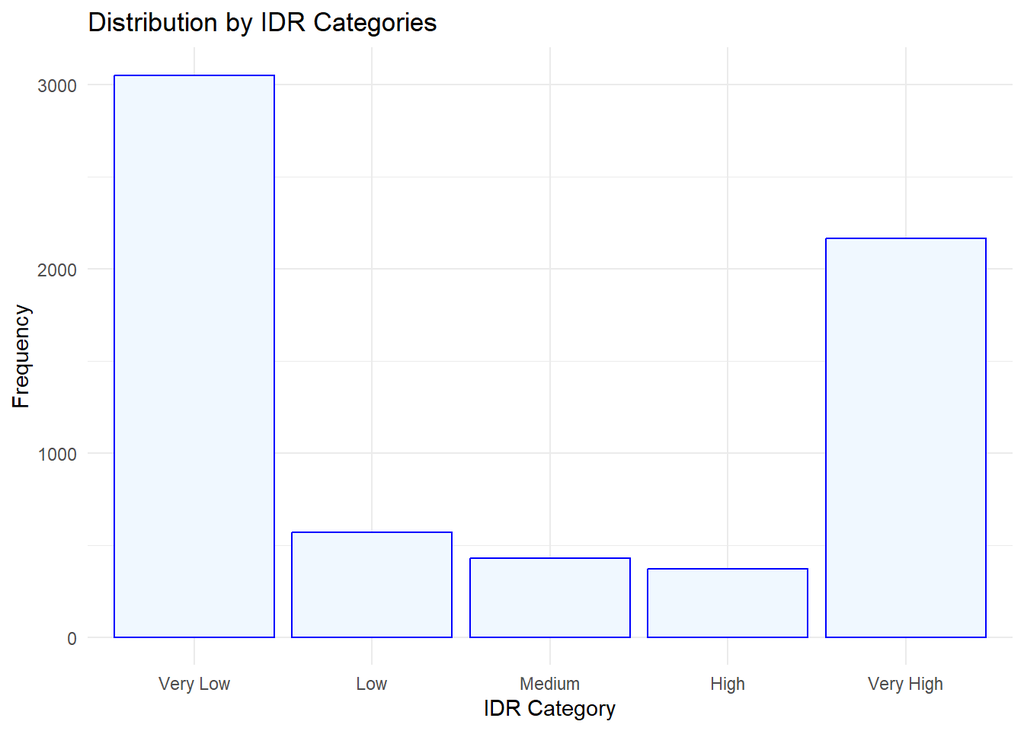

```r
#Plot a barplot of IDR categories
final_trade_df %>%
  ggplot(aes(x = `IDR Category`)) +
  geom_bar(fill = "aliceblue", color = "blue" ) +
  labs(title = "Distribution by IDR Categories",
       y = "Frequency") +
  theme_minimal()
```

The distribution by IDR categories indicates that the majority of countries fall into either the very low or very high import dependency categories, suggesting a polarization in global rice trade. Most countries are either self-sufficient or are heavily reliant on imports.

- **IDR and Regions**

  We categorized countries based on their IDR and analyzed how these categories relate to the region or continent they belong to. The following are contingency tables for 2000s and 2010s.

```r
#Contingency table and Test for IDR vs Region
#2000s
IDR_Reg_2000s <- table(trade_df_2000s$Continent,
                       trade_df_2000s$`IDR Category`)
xkabledply(IDR_Reg_2000s, title = "Contingency table for IDR vs Regions in 2000s")
```

Contingency table for IDR vs Regions in 2000s

|  | Very Low | Low | Medium | High | Very High |
| --- | --- | --- | --- | --- | --- |
| Africa | 126 | 31 | 21 | 24 | 215 |
| Americas | 160 | 9 | 12 | 10 | 76 |
| Asia | 208 | 25 | 15 | 6 | 55 |
| Europe | 24 | 11 | 16 | 13 | 46 |
| Oceania | 4 | 2 | 1 | 0 | 33 |

```r
chitest_IDR_Reg_2000s = chisq.test(IDR_Reg_2000s)
#2010s
IDR_Reg_2010s <- table(trade_df_2010s$Continent,
                       trade_df_2010s$`IDR Category`)
xkabledply(IDR_Reg_2010s, title = "Contingency table for IDR vs Regions in 2010s")
```

Contingency table for IDR vs Regions in 2010s

|  | Very Low | Low | Medium | High | Very High |
| --- | --- | --- | --- | --- | --- |
| Africa | 96 | 27 | 27 | 22 | 252 |
| Americas | 132 | 21 | 12 | 4 | 96 |
| Asia | 193 | 9 | 26 | 17 | 74 |
| Europe | 13 | 12 | 17 | 10 | 58 |
| Oceania | 0 | 0 | 2 | 1 | 37 |

```r
chitest_IDR_Reg_2010s = chisq.test(IDR_Reg_2010s)
```

The p-value for test on 2000s is 1.763^{-37} and the the p-value for test on 2010s is 8.398^{-41} . The low p-values indicate an association between region and IDR category. Countries in Africa and Europe tend to be more reliant on rice imports, while countries in Asia and the Americas are more likely to be self-sufficient.

From the contingency tables, we can also observe that in the 2010s, the number of observations in the “very high” import dependency category increased across all regions, while the opposite occurred for the “very low” import dependency category.

- **IDR and Population**

```r
#Contingency table and Test for IDR vs Population Category
#2000s
IDR_Pop_2000s <- table(trade_df_2000s$`Population Category`,
                       trade_df_2000s$`IDR Category`)
xkabledply(IDR_Pop_2000s, title = "Contingency table for IDR vs Population in 2000s")
```

Contingency table for IDR vs Population in 2000s

|  | Very Low | Low | Medium | High | Very High |
| --- | --- | --- | --- | --- | --- |
| Small | 177 | 26 | 26 | 25 | 218 |
| Medium | 204 | 30 | 29 | 23 | 184 |
| Large | 58 | 15 | 5 | 3 | 22 |

```r
chitest_IDR_Pop_2000s = chisq.test(IDR_Pop_2000s)
#2010s
###Test for IDR vs Population
IDR_Pop_2010s <- table(trade_df_2010s$`Population Category`,
                       trade_df_2010s$`IDR Category`)
xkabledply(IDR_Pop_2010s, title = "Contingency table for IDR vs Population in 2010s")
```

Contingency table for IDR vs Population in 2010s

|  | Very Low | Low | Medium | High | Very High |
| --- | --- | --- | --- | --- | --- |
| Small | 90 | 30 | 36 | 12 | 242 |
| Medium | 194 | 23 | 29 | 27 | 240 |
| Large | 60 | 7 | 13 | 10 | 30 |

```r
chitest_IDR_Pop_2010s = chisq.test(IDR_Pop_2010s)
```

#### **Conclusion and Limitations**

The analysis of global rice trade trends reveals a growing polarization in rice production and import dependency. Most countries are now either highly self-sufficient or heavily reliant on rice imports, with fewer nations falling in between. Between 2009 and 2010, there was significant shift in global rice trade trend. The results of the t-test confirm a meaningful difference in rice import volumes between the 2000s and 2010s, indicating that the global market underwent considerable changes during this period.

In terms of production patterns, the 2010s saw a noticeable increase in records of high import dependency, without a corresponding rise in self-sufficiency. This suggests that an increasing number of countries are producing less rice, leading to a global market that is becoming more reliant on a smaller group of major rice producers. The chi-squared test further supports this finding, highlighting that African and European countries were heavily affected by the change at the end of 2000s. Additionally, smaller countries in terms of population were more likely to experience higher import dependency.

While this analysis provides meaningful insight into general trends in global rice trade, it has many limitations. Information on factors such as environmental change, technological advancement on farming and transportation, which have significant impact in rice production and trade, were not included in the data but likely play a significant role in influencing rice production and trade patterns. Additionally, the re-routing and re-exporting of rice through intermediary countries complicates the accuracy of the data, potentially distorting the results.